# Clustering

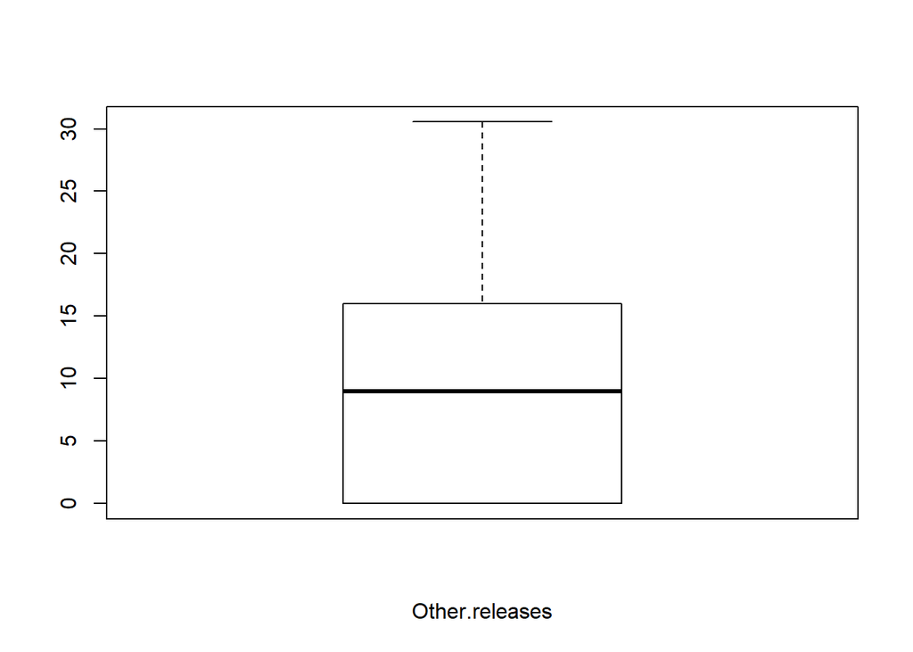

```r
the.beatles.songs.num <- fixOutliers(the.beatles.songs.num, "Other.releases")
boxplot(the.beatles.songs.num$Other.releases, xlab = "Other.releases")
```

```r
# no more outliers in Other.releases
```

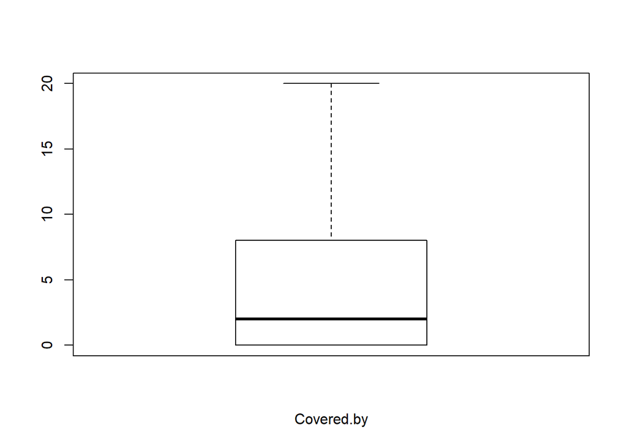

```r
the.beatles.songs.num <- fixOutliers(the.beatles.songs.num, "Covered.by")
boxplot(the.beatles.songs.num$Covered.by, xlab = "Covered.by")
```

```r
# no more outliers in Covered.by
```

Demonstrate an attempt to fix outliers with highly skewed data:

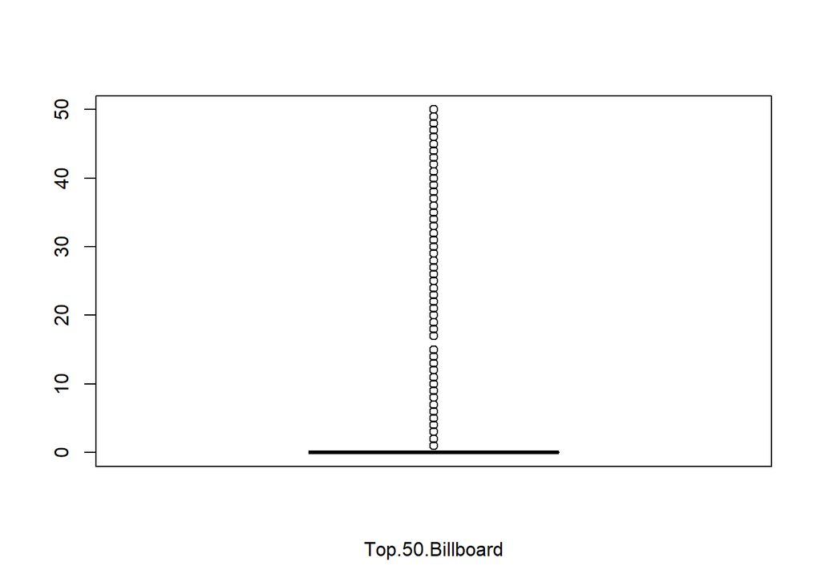

```r
boxplot(the.beatles.songs.num$Top.50.Billboard, xlab = "Top.50.Billboard")
```

```r
boxplot.stats(the.beatles.songs.num$Top.50.Billboard)
```

```
## $stats
## [1] 0 0 0 0 0
##
## $n
## [1] 310
##
## $conf
## [1] 0 0
##
## $out
##  [1] 43  1 10 36 14  3 41 45 22 25 30 13 12 47 28 44 37 50  2 40 15 49  8
## [24] 29 46 35 11  6 24 17 32 27 33  9  4 19 48 20  7 21 18  5 23 31 34 38
## [47] 42 26 39
```

```r
boxplot.stats(the.beatles.songs.num$Top.50.Billboard)$out
```

```
##  [1] 43  1 10 36 14  3 41 45 22 25 30 13 12 47 28 44 37 50  2 40 15 49  8
## [24] 29 46 35 11  6 24 17 32 27 33  9  4 19 48 20  7 21 18  5 23 31 34 38
## [47] 42 26 39
```

```r
boxplot.stats(the.beatles.songs.num$Top.50.Billboard)$stats[c(1, 5)]
```

```
## [1] 0 0
```

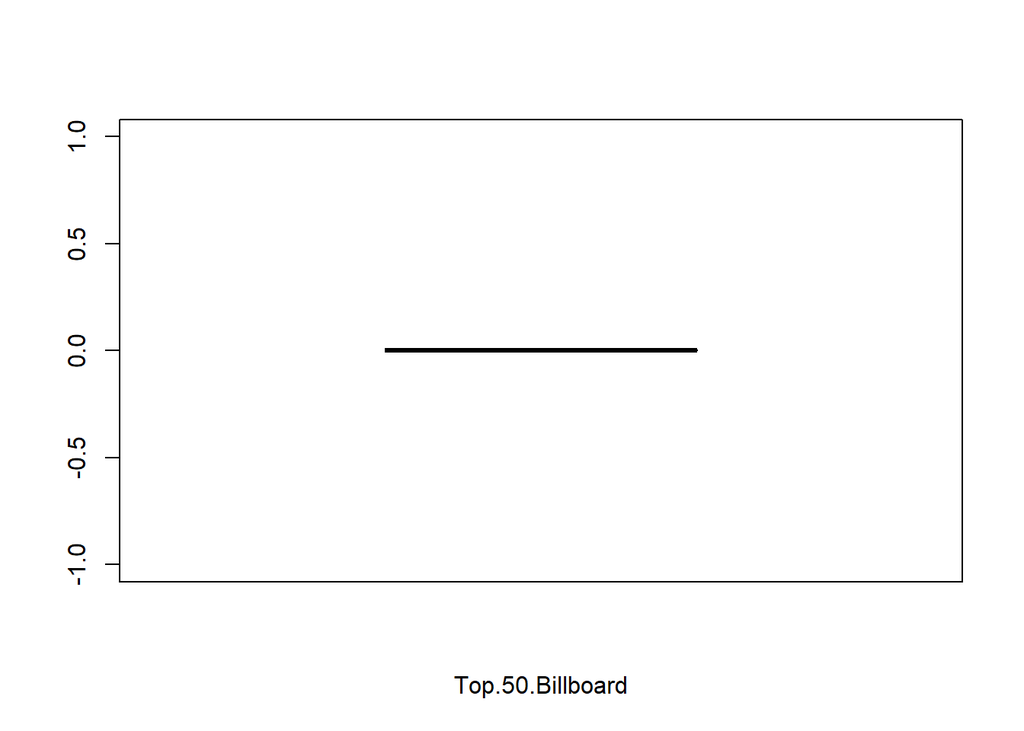

```r
temp <- the.beatles.songs.num$Top.50.Billboard # save current Top.50.Billboard, for restoring it later
the.beatles.songs.num <- fixOutliers(the.beatles.songs.num, "Top.50.Billboard")
boxplot(the.beatles.songs.num$Top.50.Billboard, xlab = "Top.50.Billboard")
```

```r
the.beatles.songs.num$Top.50.Billboard <- temp # restore Top.50.Billboard
```

Summarize the results so far:

```r
summary(the.beatles.songs.num)
```

```
##     Duration      Other.releases    Covered.by     Top.50.Billboard
##  Min.   : 91.72   Min.   : 0.00   Min.   : 0.000   Min.   : 0.000
##  1st Qu.:133.00   1st Qu.: 0.00   1st Qu.: 0.000   1st Qu.: 0.000
##  Median :150.00   Median : 9.00   Median : 2.000   Median : 0.000
##  Mean   :155.84   Mean   :10.07   Mean   : 5.323   Mean   : 4.061
##  3rd Qu.:172.75   3rd Qu.:16.00   3rd Qu.: 8.000   3rd Qu.: 0.000
##  Max.   :234.47   Max.   :30.55   Max.   :20.000   Max.   :50.000
```

### Patterns in the data

See if there are some patterns in the data, pairwise, to possibly indicate clusters:  
`pairs(~ <column 1 name> + <column 2 name> + ...,`  
`+ data = <dataframe>)`

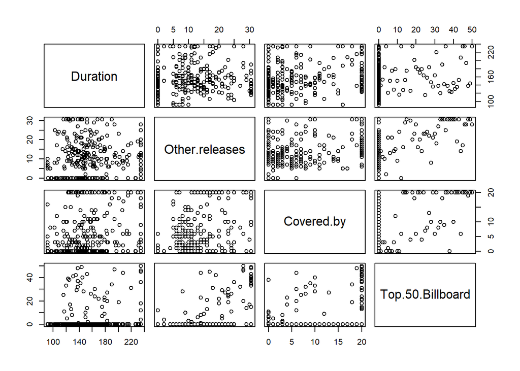

```r
pairs(~ Duration + Other.releases + Covered.by + Top.50.Billboard,  # no any striking pattern, i.e.
      the.beatles.songs.num)                                        # no visual indication of clusters
```

### K-Means with 2 variables

Try K-Means with 2 variables.

Plot the data first:  
`<scatterplot> <-` `+ ggplot(<dataset>, aes(x = <num.var.1>, y = <num.var.2>)) +`  
`+ geom_point(shape = <n>, # <n> = 1: hollow circle, no fill;`  
`+ # <n> = 21: circle that can be filled`  
`+ fill = <color 1>, # color of point fill (optional)`  
`+ color = <color 2>, # color of point line (optional)`  
`+ size = <s>) # size of point line (optional)`  
`<scatterplot> <- <scatterplot> + xlab("<x label>") # label/caption on x-axis`  
`<scatterplot> <- <scatterplot> + ylab("<y label>") # label/caption on y-axis`  
`<scatterplot> <- <scatterplot> + ggtitle("<scatterplot title>") # scatterplot title`  
`<scatterplot> # plot it`

Alternatively:  
`<scatterplot> <-`  
`+ ggplot(<dataset>, aes(x = <num.var.1>, y = <num.var.2>)) +`  
`+ geom_point(shape = <n>, # <n> = 1: hollow circle, no fill;`  
`+ # <n> = 21: circle that can be filled`  
`+ fill = <color 1>, # color of point fill (optional)`  
`+ color = <color 2>, # color of point line (optional)`  
`+ size = <s>) # size of point line (optional)`  
`<scatterplot> <- <scatterplot> +`  
`+ labs(x = "<x label>", # label/caption on x-axis`  
`+ y = "<y label>", # label/caption on y-axis`  
`+ title = "<scatterplot title>") + # scatterplot title`  
`<scatterplot> # plot it`

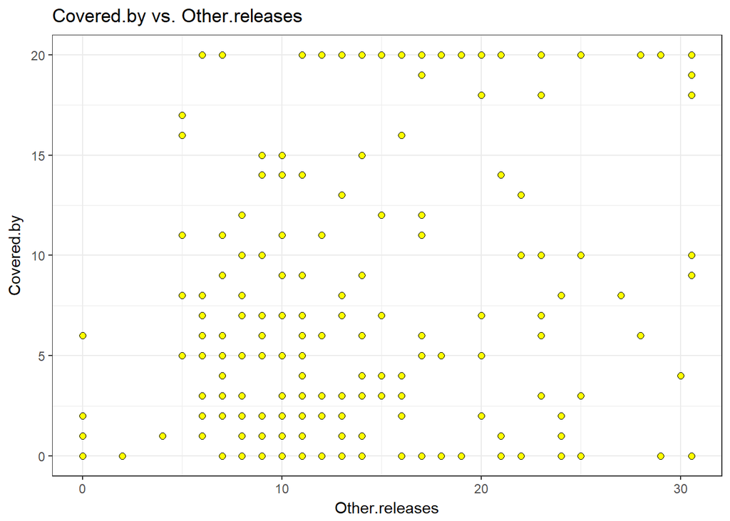

```r
scatterplot.Other.releases.vs.Covered.by <-
  ggplot(the.beatles.songs.num, aes(x = Other.releases, y = Covered.by)) +
  geom_point(shape = 21, fill = "yellow", size = 2) +
  labs(x = "Other.releases", y = "Covered.by", title = "Covered.by vs. Other.releases") +
  theme_bw()
scatterplot.Other.releases.vs.Covered.by
```

Subset the original data to include only the variables to be used in K-Means:  
`<new dataframe> <- <dataframe>[, c("<col1 name>", "<col2 name>")]`  
`<new dataframe> <- <dataframe>[, <col1 index>:<col2 index>]`  
Alternatively:  
`<new dataframe> <- subset(<dataframe>, select = c("<col1 name>", "<col2 name>"))`  
`<new dataframe> <- subset(<dataframe>, select = c(<col1 index>:<col2 index>))`

```r
the.beatles.songs.num.1 <- the.beatles.songs.num[, c("Other.releases", "Covered.by")]
# the.beatles.songs.num.1 <- subset(the.beatles.songs.num, select = c("Other.releases", "Covered.by"))
summary(the.beatles.songs.num.1)
```

```
##  Other.releases    Covered.by
##  Min.   : 0.00   Min.   : 0.000
##  1st Qu.: 0.00   1st Qu.: 0.000
##  Median : 9.00   Median : 2.000
##  Mean   :10.07   Mean   : 5.323
##  3rd Qu.:16.00   3rd Qu.: 8.000
##  Max.   :30.55   Max.   :20.000
```

```r
head(the.beatles.songs.num.1)
```

```
##                            Other.releases Covered.by
## 12-Bar Original                      0.00          0
## A Day in the Life                   12.00         20
## A Hard Day's Night                  30.55         20
## A Shot of Rhythm and Blues           0.00          0
## A Taste of Honey                    29.00          0
## Across the Universe                 19.00         20
```

### Data normalization

Required by K-Means when the variables have different ranges.  
`range(<dataframe with numeric columns>$<numeric column 1> # check the range of <numeric column 1>`  
`range(<dataframe with numeric columns>$<numeric column 2> # check the range of <numeric column 2>`  
`...`  
`# install.packages("clusterSim")`  
`library(clusterSim)`  
`<dataframe with numeric columns> <- # works with vectors and matrices as well`  
`+ data.Normalization(<dataframe with numeric columns>,`  
`+ type = "n4", # normalization: (x - min(x)) / (max(x) - min(x))`  
`+ normalization = "column") # normalization by columns`

```r
range(the.beatles.songs.num.1$Other.releases)
```

```
## [1]  0.00 30.55
```

```r
range(the.beatles.songs.num.1$Covered.by)
```

```
## [1]  0 20
```

```r
library(clusterSim)
the.beatles.songs.num.2 <-
  data.Normalization(the.beatles.songs.num.1,
                     type = "n4",
                     normalization = "column")
tail(the.beatles.songs.num.2)
```

```
##                                   Other.releases Covered.by
## You'll Be Mine                        0.00000000       0.00
## You're Going to Lose That Girl        0.19639935       0.10
## You've Got to Hide Your Love Away     0.39279869       1.00
## You've Really Got a Hold on Me        0.06546645       0.00
## Young Blood                           0.00000000       0.00
## Your Mother Should Know               0.42553191       0.05
```

### K-Means for K = 3

Run K-Means for K = 3:  
`set.seed(<seed>)`  
`<clusters> <- kmeans(x = <normalized dataframe>,`  
`+ centers = 3, # K = 3`  
`+ iter.max = 20, # max number of iterations allowed`  
`+ nstart = 1000) # no. of initial configurations`  
`+ # (report generated based on the best one)`  
`<clusters>`

```r
set.seed(888)
clusters.K3 <- kmeans(x = the.beatles.songs.num.2, centers = 3, iter.max = 20, nstart = 1000)
clusters.K3
```

```
## K-means clustering with 3 clusters of sizes 103, 149, 58
##
## Cluster means:
##   Other.releases Covered.by
## 1     0.53862044  0.2189320
## 2     0.08633662  0.0466443
## 3     0.58352616  0.9137931
##
## Clustering vector:
##                                           12-Bar Original
##                                                         2
##                                         A Day in the Life
##                                                         3
##                                        A Hard Day's Night
##                                                         3
##                                A Shot of Rhythm and Blues
##                                                         2
##                                          A Taste of Honey
##                                                         1
##                                       Across the Universe
##                                                         3
##                                             Act Naturally
##                                                         1
##                                           Ain't She Sweet
##                                                         2
##                                        All I've Got to Do
##                                                         2
##                                             All My Loving
##                                                         3
##                                      All Things Must Pass
##                                                         2
##                                          All Together Now
##                                                         2
##                                      All You Need Is Love
##                                                         3
##                                            And I Love Her
##                                                         3
##                                    And Your Bird Can Sing
##                                                         1
##                                          Anna (Go to Him)
```

[output cut: 584 more lines]

```
##                                                         2
##                                               Young Blood
##                                                         2
##                                   Your Mother Should Know
##                                                         1
##
## Within cluster sum of squares by cluster:
## [1] 8.245325 3.317424 5.057079
##  (between_SS / total_SS =  74.6 %)
##
## Available components:
##
## [1] "cluster"      "centers"      "totss"        "withinss"
## [5] "tot.withinss" "betweenss"    "size"         "iter"
## [9] "ifault"
```

The meaning of parameters in the report:

- withinss (within_SS) - within cluster sum of squares, i.e., sum of squared differences between individual data points in a cluster and the cluster center; it is computed for each cluster
- totss (total_SS) - the sum of squared differences of each data point to the global sample mean
- betweenss (between_SS) - the sum of squared differences of each cluster center to the global sample mean; the squared difference of each cluster center to the global sample mean is multiplied by the number of data points in that cluster
- tot.withinss - the sum of squared differences between data points and cluster centers (the sum of within_SS for all the clusters)
- between_SS / total_SS - indicates how well the sample splits into clusters; the higher the ratio, the better clustering

Add the vector of clusters to the dataframe:  
`<normalized dataframe>$<new column> <- factor(<clusters>$cluster) # <clusters>: from the previous step`  
`head(<normalized dataframe>)`

```r
the.beatles.songs.num.2$Cluster <- factor(clusters.K3$cluster)
head(the.beatles.songs.num.2)
```

```
##                            Other.releases Covered.by Cluster
## 12-Bar Original                 0.0000000          0       2
## A Day in the Life               0.3927987          1       3
## A Hard Day's Night              1.0000000          1       3
## A Shot of Rhythm and Blues      0.0000000          0       2
## A Taste of Honey                0.9492635          0       1
## Across the Universe             0.6219313          1       3
```

Plot the clusters in a new scatterplot, using plotClusters() utility function:  
`source("Plot clusters.R")`  
`plotClusters() <- function(dataset, # dataset with the cluster column`  
`+ xcol, # dataset column for the x-axis, passed as a string`  
`+ ycol, # dataset column for the y-axis, passed as a string`  
`+ clustercol, # dataset column showing the clusters, passed as a string`  
`+ title, # plot title`  
`+ x.label, # x-axis label`  
`+ y.label, # y-axis label`  
`+ legend.label, # plot legend label`  
`+ show.centers.flag, # plot cluster centers if TRUE`  
`+ clusters) { # clusters computed by kmeans() in a previous step`

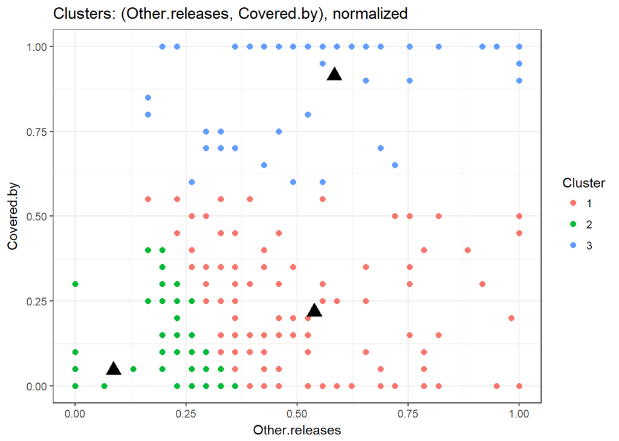

```r
source("Plot clusters.R")
plotClusters(the.beatles.songs.num.2,
             "Other.releases",
             "Covered.by",
             "Cluster",
             "Clusters: (Other.releases, Covered.by), normalized",
             "Other.releases",
             "Covered.by",
             "Cluster",
             TRUE,
             clusters.K3)
```

### Optimal value for K

Find the optimal value for K, using the Elbow method (a call to the appropriate utility function); an appropriate dataframe should be passed as the parameter (just numeric variables, no clusters):  
`source("Elbow method.R")`  
`<elbow parameters> <- getElbowMethodParameters(<dataframe>[, c(<n1>, <n2>, ...)]) # leave out the cluster column`  
`<elbow parameters>`  
`plotElbow(<elbow parameters>)`

```r
source("Elbow method.R")
elbow.2 <- getElbowMethodParameters(the.beatles.songs.num.2[, c(1,2)])   # remove the Cluster column
elbow.2
```

```
##   cluster tot.withinss between_SS / total_SS
## 1       2    27.784582             0.5752468
## 2       3    16.619828             0.7459265
## 3       4    11.367590             0.8262194
## 4       5     8.106076             0.8760794
## 5       6     6.345421             0.9029952
## 6       7     5.040072             0.9229506
## 7       8     4.171462             0.9362293
```

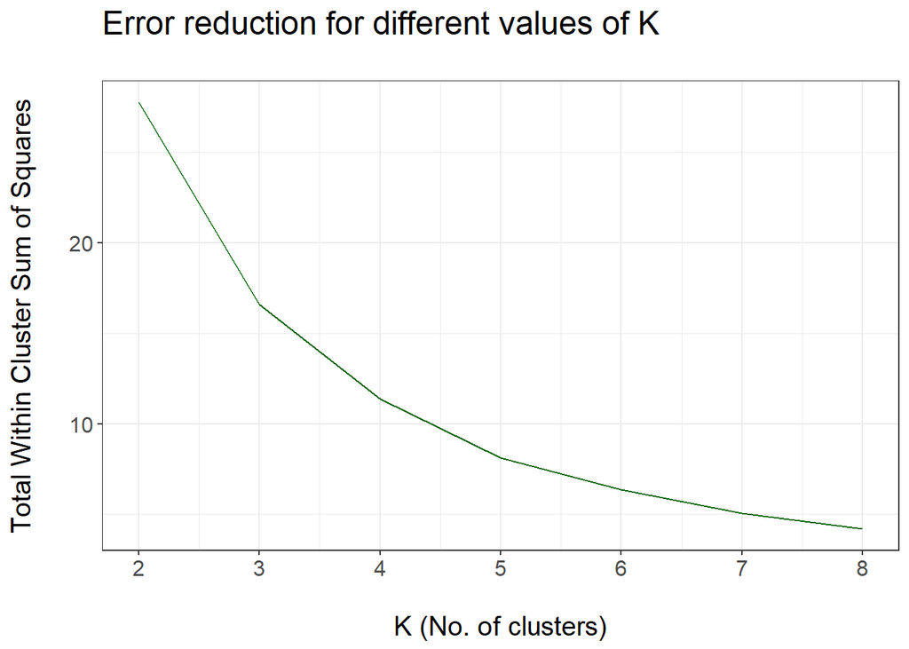

```r
plotElbow(elbow.2)
```

Show differences in tot.withinss for different values of K more precisely, using the getDifferences() utility function:  
`source("Elbow method.R")`  
`<diff dataframe> <-`  
`+ data.frame(K = <n1>:<n2>,`  
`+ diff.tot.withinss =`  
`+ getDifferences(<elbow stats>$<tot.withinss>), # from the previous step`  
`+ diff.ratio =`  
`+ getDifferences(<elbow stats>$<ratio between_SS / total_SS>)) # from the previous step`  
`names(<diff dataframe>) <- c("K", "Difference in tot.withinss", "Difference in between_SS / total_SS")`  
`<diff dataframe>`

```r
df.differences <- data.frame(K = 2:8,
                             getDifferences(elbow.2[, 2]),
                             getDifferences(elbow.2[, 3]))
names(df.differences) <- c("K", "Difference in tot.withinss", "Difference in between_SS / total_SS")
df.differences
```

```
##   K Difference in tot.withinss Difference in between_SS / total_SS
## 1 2                         NA                                  NA
## 2 3                 11.1647543                          0.17067974
## 3 4                  5.2522373                          0.08029290
## 4 5                  3.2615145                          0.04985998
## 5 6                  1.7606546                          0.02691578
## 6 7                  1.3053496                          0.01995536
## 7 8                  0.8686101                          0.01327877
```

### K-Means for K = 4

Run K-Means also for K = 4:

```r
set.seed(818)
the.beatles.songs.num.2 <- the.beatles.songs.num.2[, -3]    # remove the Cluster column for the new run
clusters.K4 <- kmeans(x = the.beatles.songs.num.2, centers = 4, iter.max = 20, nstart = 1000)
clusters.K4
```

```
## K-means clustering with 4 clusters of sizes 58, 98, 41, 113
##
## Cluster means:
##   Other.releases  Covered.by
## 1    0.588605452 0.912931034
## 2    0.003340125 0.005102041
## 3    0.767115085 0.186585366
## 4    0.320959402 0.189380531
##
## Clustering vector:
##                                           12-Bar Original
##                                                         2
##                                         A Day in the Life
##                                                         1
##                                        A Hard Day's Night
##                                                         1
##                                A Shot of Rhythm and Blues
##                                                         2
##                                          A Taste of Honey
##                                                         3
##                                       Across the Universe
##                                                         1
##                                             Act Naturally
##                                                         4
##                                           Ain't She Sweet
##                                                         4
##                                        All I've Got to Do
##                                                         4
##                                             All My Loving
##                                                         1
##                                      All Things Must Pass
##                                                         2
##                                          All Together Now
##                                                         4
##                                      All You Need Is Love
##                                                         1
##                                            And I Love Her
##                                                         1
##                                    And Your Bird Can Sing
##                                                         4
```

[output cut: 585 more lines]

```
##                                                         2
##                                               Young Blood
##                                                         2
##                                   Your Mother Should Know
##                                                         4
##
## Within cluster sum of squares by cluster:
## [1] 4.9866854 0.1313566 2.3811301 3.8684182
##  (between_SS / total_SS =  82.6 %)
##
## Available components:
##
## [1] "cluster"      "centers"      "totss"        "withinss"
## [5] "tot.withinss" "betweenss"    "size"         "iter"
## [9] "ifault"
```

```r
the.beatles.songs.num.2$Cluster <- factor(clusters.K4$cluster)
head(the.beatles.songs.num.2)
```

```
##                            Other.releases Covered.by Cluster
## 12-Bar Original                 0.0000000          0       2
## A Day in the Life               0.3927987          1       1
## A Hard Day's Night              1.0000000          1       1
## A Shot of Rhythm and Blues      0.0000000          0       2
## A Taste of Honey                0.9492635          0       3
## Across the Universe             0.6219313          1       1
```

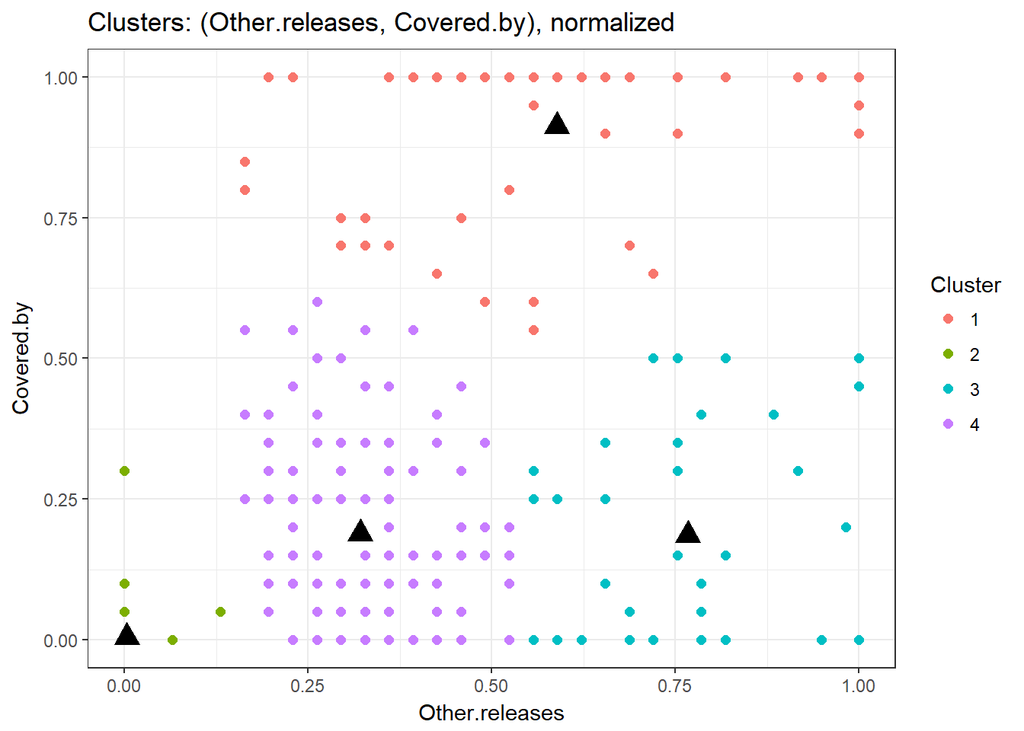

```r
source("Plot clusters.R")
plotClusters(the.beatles.songs.num.2,
             "Other.releases",
             "Covered.by",
             "Cluster",
             "Clusters: (Other.releases, Covered.by), normalized",
             "Other.releases",
             "Covered.by",
             "Cluster",
             TRUE,
             clusters.K4)
```

Examine clusters more closely by looking into the cluster centers (means) and standard deviations from the centers. In doing so, use ‘regular’ (not normalized) features and the summarizeClusterStats() utility function:  
`source("Summary statistics about clusters.R")`  
`<stats dataframe> <-`  
`+ summarizeClusterStats(feature.set = <dataframe with 'regular' (not normalized) features>,`  
`+ clusters = <clusters>$cluster, # <clusters>: result of kmeans()`  
`+ cl.num = <K>) # <K>: number of clusters`  
Compare dispersion (sd) in this representation of the data and in the corresponding plots.`

```r
source("Summary statistics about clusters.R")
clusters.K3.stats <- summarizeClusterStats(feature.set = the.beatles.songs.num.1,
                                           clusters = clusters.K3$cluster, cl.num = 3)
clusters.K4.stats <- summarizeClusterStats(feature.set = the.beatles.songs.num.1,
                                           clusters = clusters.K4$cluster, cl.num = 4)
```

### K-Means with all variables

Data normalization:

```r
library(clusterSim)
the.beatles.songs.num.4 <-
  data.Normalization(the.beatles.songs.num,
                     type = "n4",
                     normalization = "column")
tail(the.beatles.songs.num.4)
```

```
##                                     Duration Other.releases Covered.by
## You'll Be Mine                    0.04395797     0.00000000       0.00
## You're Going to Lose That Girl    0.33817863     0.19639935       0.10
## You've Got to Hide Your Love Away 0.27513135     0.39279869       1.00
## You've Really Got a Hold on Me    0.63239930     0.06546645       0.00
## Young Blood                       0.17005254     0.00000000       0.00
## Your Mother Should Know           0.40122592     0.42553191       0.05
##                                   Top.50.Billboard
## You'll Be Mine                                   0
## You're Going to Lose That Girl                   0
## You've Got to Hide Your Love Away                0
## You've Really Got a Hold on Me                   0
## Young Blood                                      0
## Your Mother Should Know                          0
```

Find the optimal value for K, using the Elbow method (a call to the appropriate utility function):

```r
source("Elbow method.R")
elbow.4 <- getElbowMethodParameters(the.beatles.songs.num.4)
elbow.4
```

```
##   cluster tot.withinss between_SS / total_SS
## 1       2     57.11964             0.4301936
## 2       3     45.92685             0.5418492
## 3       4     35.76960             0.6431745
## 4       5     27.82075             0.7224695
## 5       6     24.28521             0.7577389
## 6       7     21.46786             0.7858438
## 7       8     19.09187             0.8095459
```

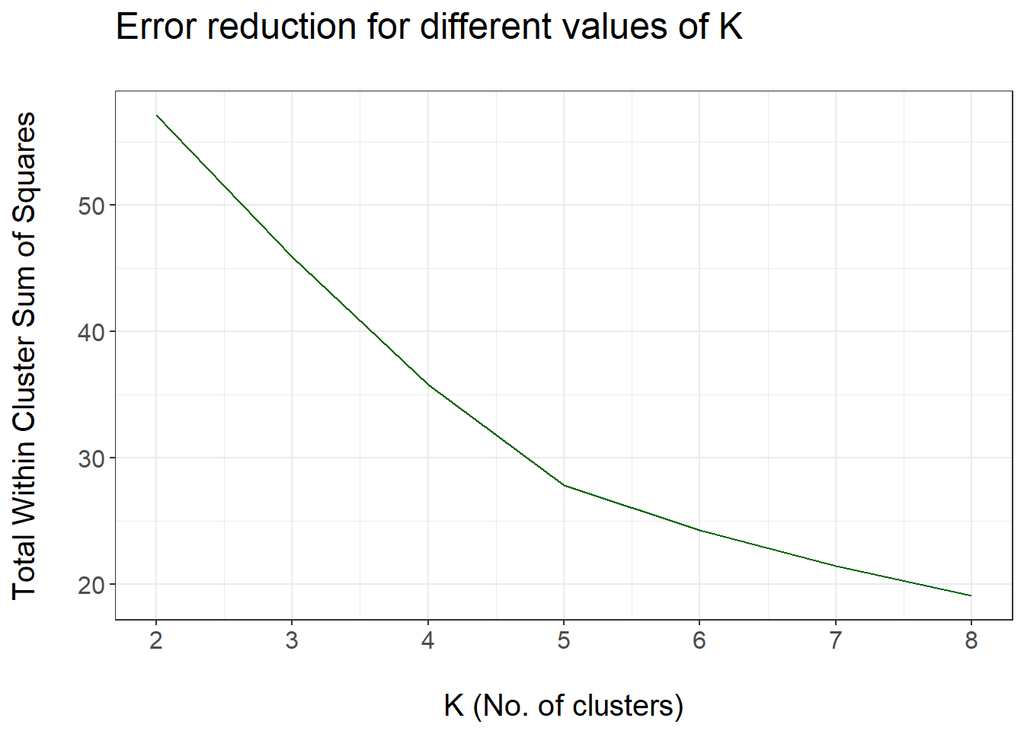

```r
plotElbow(elbow.4)
```

Show differences in tot.withinss for different values of K more precisely, using the getDifferences() utility function:

```r
df.differences <- data.frame(K = 2:8,
                             getDifferences(elbow.4[, 2]),
                             getDifferences(elbow.4[, 3]))
names(df.differences) <- c("K", "Difference in tot.withinss", "Difference in between_SS / total_SS")
df.differences
```

```
##   K Difference in tot.withinss Difference in between_SS / total_SS
## 1 2                         NA                                  NA
## 2 3                  11.192793                          0.11165555
## 3 4                  10.157254                          0.10132536
## 4 5                   7.948846                          0.07929502
## 5 6                   3.535538                          0.03526934
## 6 7                   2.817348                          0.02810492
## 7 8                   2.375991                          0.02370209
```

```r
set.seed(888)
clusters.K3.all.vars <- kmeans(x = the.beatles.songs.num.4, centers = 3, iter.max = 20, nstart = 1000)
clusters.K3.all.vars
```

```
## K-means clustering with 3 clusters of sizes 112, 135, 63
##
## Cluster means:
##    Duration Other.releases Covered.by Top.50.Billboard
## 1 0.4690799     0.48754968 0.20446429      0.035000000
## 2 0.3746786     0.06789113 0.03518519      0.003851852
## 3 0.5731271     0.60977321 0.87063492      0.329206349
##
## Clustering vector:
##                                           12-Bar Original
##                                                         2
##                                         A Day in the Life
##                                                         3
##                                        A Hard Day's Night
##                                                         3
##                                A Shot of Rhythm and Blues
##                                                         2
##                                          A Taste of Honey
##                                                         1
##                                       Across the Universe
##                                                         3
##                                             Act Naturally
##                                                         1
##                                           Ain't She Sweet
##                                                         2
##                                        All I've Got to Do
##                                                         2
##                                             All My Loving
##                                                         3
##                                      All Things Must Pass
##                                                         2
##                                          All Together Now
##                                                         2
##                                      All You Need Is Love
##                                                         3
##                                            And I Love Her
##                                                         3
##                                    And Your Bird Can Sing
##                                                         1
##                                          Anna (Go to Him)
```

[output cut: 584 more lines]

```
##                                                         2
##                                               Young Blood
##                                                         2
##                                   Your Mother Should Know
##                                                         1
##
## Within cluster sum of squares by cluster:
## [1] 16.019939  9.727616 20.179295
##  (between_SS / total_SS =  54.2 %)
##
## Available components:
##
## [1] "cluster"      "centers"      "totss"        "withinss"
## [5] "tot.withinss" "betweenss"    "size"         "iter"
## [9] "ifault"
```

Run K-Means also for K = 4, since K = 4 seems to be the next best value for K:

```r
set.seed(888)
clusters.K4.all.vars <- kmeans(x = the.beatles.songs.num.4, centers = 4, iter.max = 20, nstart = 1000)
clusters.K4.all.vars
```

```
## K-means clustering with 4 clusters of sizes 31, 99, 46, 134
##
## Cluster means:
##    Duration Other.releases Covered.by Top.50.Billboard
## 1 0.5284278     0.85169738 0.77096774      0.684516129
## 2 0.4715880     0.48592306 0.16464646      0.016767677
## 3 0.5805490     0.40742190 0.81086957      0.038695652
## 4 0.3690436     0.06668784 0.03731343      0.003880597
##
## Clustering vector:
##                                           12-Bar Original
##                                                         4
##                                         A Day in the Life
##                                                         3
##                                        A Hard Day's Night
##                                                         1
##                                A Shot of Rhythm and Blues
##                                                         4
##                                          A Taste of Honey
##                                                         2
##                                       Across the Universe
##                                                         3
##                                             Act Naturally
##                                                         2
##                                           Ain't She Sweet
##                                                         4
##                                        All I've Got to Do
##                                                         4
##                                             All My Loving
##                                                         3
##                                      All Things Must Pass
##                                                         4
##                                          All Together Now
##                                                         4
##                                      All You Need Is Love
##                                                         1
##                                            And I Love Her
##                                                         1
##                                    And Your Bird Can Sing
##                                                         2
```

[output cut: 585 more lines]

```
##                                                         4
##                                               Young Blood
##                                                         4
##                                   Your Mother Should Know
##                                                         2
##
## Within cluster sum of squares by cluster:
## [1]  7.051222 11.577611  7.337453  9.803310
##  (between_SS / total_SS =  64.3 %)
##
## Available components:
##
## [1] "cluster"      "centers"      "totss"        "withinss"
## [5] "tot.withinss" "betweenss"    "size"         "iter"
## [9] "ifault"
```

Examine and compare the cluster centers for K = 3 and K = 4:

```r
clusters.K3.all.vars.stats <- summarizeClusterStats(feature.set = the.beatles.songs.num,
                                                    clusters = clusters.K3.all.vars$cluster, cl.num = 3)
clusters.K3.all.vars.stats
```

```
##                                 Cluster 1     Cluster 2    Cluster 3
## Frequency                             112           135           63
## Duration (mean, sd)         158.69, 33.04 145.21, 33.22 173.54, 39.9
## Other.releases (mean, sd)     14.89, 6.42    2.07, 3.34  18.63, 8.38
## Covered.by (mean, sd)          4.09, 3.56     0.7, 1.51  17.41, 3.88
## Top.50.Billboard (mean, sd)    1.75, 6.12    0.19, 1.38 16.46, 18.34
```

```r
clusters.K4.all.vars.stats <- summarizeClusterStats(feature.set = the.beatles.songs.num,
                                                    clusters = clusters.K4.all.vars$cluster, cl.num = 4)
clusters.K4.all.vars.stats
```

```
##                                 Cluster 1     Cluster 2    Cluster 3
## Frequency                              31            99           46
## Duration (mean, sd)         167.16, 37.47 159.04, 32.44 174.6, 40.04
## Other.releases (mean, sd)     26.02, 4.93   14.84, 6.15  12.45, 5.42
## Covered.by (mean, sd)         15.42, 6.25    3.29, 2.95  16.22, 3.92
## Top.50.Billboard (mean, sd)  34.23, 10.28    0.84, 3.28   1.93, 6.01
##                                 Cluster 4
## Frequency                             134
## Duration (mean, sd)         144.41, 33.31
## Other.releases (mean, sd)      2.04, 3.33
## Covered.by (mean, sd)          0.75, 1.63
## Top.50.Billboard (mean, sd)    0.19, 1.38
```

### Compare multiple clustering results/schemes

`# install.packages("fpc")`  
`library(fpc)`  
`?cluster.stats`  
`<comparison criteria> <- # specify criteria (from cluster.stats()) for comparing`  
`+ c("<criterion 1>", # different clusterings (e.g., "max.diameter", "min.separation",`  
`+ "<criterion 2>", ...) # "average.between", "average.within", "within.cluster.ss", ...)`  
`<distance matrix> <-`  
`+ dist(x = <normalized dataset>)`  
`<comparison> <- sapply(list(<clustering 1 name> = <clustering 1>$cluster, # <clustering 1> computed by kmeans()`  
`+ <clustering 2 name> = <clustering 2>$cluster, # <clustering 2> computed by kmeans()`  
`+ ...)`  
`+ FUN = function(x)`  
`+ cluster.stats(<distance matrix>, x))[<comparison criteria>, ]`  
Alternative 1 - show output as a table in the console:  
`# install.packages("knitr")`  
`library(knitr)`  
`kable(x = <comparison>, format = "rst")`  
Alternative 2 - show output as a dataframe, using an appropriate utility function:  
`source("Summary statistics about clusters.R")`  
`<comparison.df> <-`  
`+ compareMultipleClusterings(<comparison>) # show comparison as a dataframe, using a corresponding utility function`  
`<comparison.df>`

```r
library(fpc)
comparison.criteria <- c("max.diameter", "min.separation", "average.between",
                         "average.within", "within.cluster.ss")
d <- dist(x = the.beatles.songs.num.4)
comparison <- sapply(list(c.K3.var2 = clusters.K3$cluster, # clustering: 3 clusters, 2 variables
                          c.K4.var2 = clusters.K4$cluster, # clustering: 4 clusters, 2 variables
                          c.K3.var4 = clusters.K3.all.vars$cluster,  # 3 clusters, 4 variables
                          c.K4.var4 = clusters.K4.all.vars$cluster), # 4 clusters, 4 variables
                     FUN = function(x) cluster.stats(d, x))[comparison.criteria, ]

# Alternative 1 - show output as a table in the console:
# library(knitr)
# kable(x = comparison, format = "rst")

# Alternative 2 - show output as a dataframe, using an appropriate utility function:
comparison.df <- compareMultipleClusterings(comparison)
comparison.df
```

```
##                     c.K3.var2   c.K4.var2   c.K3.var4   c.K4.var4
## max.diameter       1.61456014  1.61456014  1.61456014  1.34330166
## min.separation     0.03889892  0.05327394  0.07306239  0.07306239
## average.between    0.86906146  0.82500969  0.86156342  0.85727127
## average.within     0.43265401  0.40330399  0.42781533  0.38151663
## within.cluster.ss 47.00207948 41.22975881 45.92684939 35.76959542
```